# Detecting Volcanoes on Venus via Classification

Team Mamamia!:Di Ye (diye2), Hao Wang (haow2), Hannah Pu (chpu2)

Abstract

LASSO Regression, logistic regression, neural network, random forest, and xgboost have been used in this project to identify whether each image in the Kaggle datasets contains volcanoes or not, and if there is any, how many volcanoes are there. The analysis of the images revealed that there are several volcanoes on Venus. Neural network xgboost both had good performance to identify whether the images have volcanoes in this project for image classification with an area under the curve of 0.9629 (neural network) and 0.9680 (xgboost), and F-1 score of 0.9747 (neural network) and 0.9628 (xgboost). The comparison between different models is also included.

## I. INTRODUCTION

It is well known that Venus is the closest planet to Earth. However, the surface of Venus is obscured by layers of thick cloud cover. It was until NASA’s Magellan spacecraft was launched off for a mission to Venus on May 4, 1989 that the first detailed information about the surface of Venus was revealed. The mission mapped surfaces of Venus and image recorded most 98% of Venus surface. Dr. King in his article *Volcanoes on Venus* has mentioned that “volcanic activity is the dominant process for shaping the landscape of Venus, with over 90% of the planet’s surface being covered by lava flows and shield volcanoes”. Based on the images of volcanoes on Venus, we aim to construct prediction model to identify whether an image contains volcanoes or not, and how many volcanoes are there. **Figure 1** is a simulated color image of the surface of Venus created by NASA using radar topography data acquired by the Magellan spacecraft.

[figure not shown]

Volcanoes on Venus

### Data Source Information

The data was downloaded from Kaggle, which is originally from NASA’s Magellan spacecraft database. (https://www.kaggle.com/amantheroot/finding-volcanoes-on-venus/data)

### Data Description

9734 images were captured by the NASA’s Magellan spacecraft in the 1990s and converted to pixels (110 x 110, from 0 to 255), where each image is one row of 12100 columns (all the 110 rows of 110 columns). Images can contain more than one volcanoes or maybe none. The 9000+ images are separated to four datasets (file names : *train_images*, *train_labels*, *test_images*, and *test_labels*):

#### Image Dataset (*train_images* and *test_images*)

*Train_images* : 7000 images as train data with 12100 variables;  
*Test_images* : 2734 images as test data with 12100 variables; All the variables (V1 to V12100) correspond to the pixel image, 110 pixels * 110 pixels = 12100 pixels.

#### Label Dataset (*train_labels* and *test_labels*)

A summary of the variables in both *train_labels* and *test_label* datasets is listed down below:  
1. *Volcano?* : If in the image there exists at least one volcano, the label is 1 (Yes). Otherwise, the label is 0 (No). (If Volcano? equals 0, the following three categories would be “NaN”). 2. *Type* : 1 = definitely a volcano,2 = probably, 3 = possibly, 4 = only a pit is visible  
3. *Radius* : Is the radius of the volcano in the center of the image, in pixels?  
4. *Number Volcanoes* : The number of volcanoes in the image.

### Literature Review

These venus datasets were uploaded in Kaggle and 11 kernels regarding this data analysis were produced, all using Python. The kernels included vivid data visualization and exploratory data. Most kernels focused on classification prediction on whether there are volcanoes or not. For this classification prediction, different methods have been used to construct prediction model, from simple models such as logistic regression, to advanced models such as Convolutional Neural Network (CNN) and VGG Neural Network for deep learning. Accuracy of models ranged from 84.1% to 97%.

### Scientific Goal

For this project, we focus mainly on doing classification predition on whether each image has a volcano or not. We aim in constructing different classification models and choosing the best model to predict whether there exists a valcano in each image. Identifying valcanoe through IT technology would increase the efficency of space exploration and safty of the crews. In addition, we also constructed a few models to perform prediction on the number of volcanoes in the images.

## II. EXPLORATORY DATA

The first 6 observations of *train_labels*

```r
head(train_y)
```

```
##   Volcano. Type Radius Number.Volcanoes
## 1        1    3  17.46                1
## 2        0  NaN    NaN              NaN
## 3        0  NaN    NaN              NaN
## 4        0  NaN    NaN              NaN
## 5        0  NaN    NaN              NaN
## 6        0  NaN    NaN              NaN
```

The first 6 observations of *test_labels*

```r
head(test_y)
```

```
##   Volcano. Type Radius Number.Volcanoes
## 1        0  NaN    NaN              NaN
## 2        0  NaN    NaN              NaN
## 3        1    1  17.00                1
## 4        0  NaN    NaN              NaN
## 5        1    3  15.13                1
## 6        0  NaN    NaN              NaN
```

After exploring the datasets, we found only labels have NaNs. The NaNs in the label dataset occurs only when there is no Volcanoe in the image observation, then `Type`, `Radius` and `Number.Volcanoes` would be NaNs as there are no volcanoes. We have set the all these NaNs to 0.

```r
test_y[is.na(test_y$Type), ] <- 0
test_y[is.na(test_y$Radius), ] <- 0
test_y[is.na(test_y$Number.Volcanoes), ] <- 0
train_y[is.na(train_y$Type), ] <- 0
train_y[is.na(train_y$Radius), ] <- 0
train_y[is.na(train_y$Number.Volcanoes), ] <- 0
```

The first 6 observations of *train_labels* after setting NaNs to 0

```r
head(train_y)
```

```
##   Volcano. Type Radius Number.Volcanoes
## 1        1    3  17.46                1
## 2        0    0   0.00                0
## 3        0    0   0.00                0
## 4        0    0   0.00                0
## 5        0    0   0.00                0
## 6        0    0   0.00                0
```

The first 6 observations of *test_labels* after setting NaNs to 0

```r
head(test_y)
```

```
##   Volcano. Type Radius Number.Volcanoes
## 1        0    0   0.00                0
## 2        0    0   0.00                0
## 3        1    1  17.00                1
## 4        0    0   0.00                0
## 5        1    3  15.13                1
## 6        0    0   0.00                0
```

### Data Visualization

6 observations are picked to demonstrate how the images got labeled. **Figure 2 - 5** show how well the volcanoes can be seen from the images (*Type* : 1 = definitely a volcano,2 = probably, 3 = possibly, 4 = only a pit is visible). **Figure 6** contains 2 volcanoes, and **Figure 7** contains no volcano at all. We can tell from the images that a bright white dot indicates a potential volcano, while the white dot might not be clear enough to see in the image, which means that it is hard to identify whether there is a volcano or not.

The following `volplot` function is written for plotting some sample images.

```r
volplot <- function(data, obs){
  im <- as.numeric(data[obs,])
  m <- matrix(im, nrow = 110, byrow = TRUE)
  image(m, col = grey((0:255)/255))
}
```

An example code for plotting the 10th observation in the *train_images*

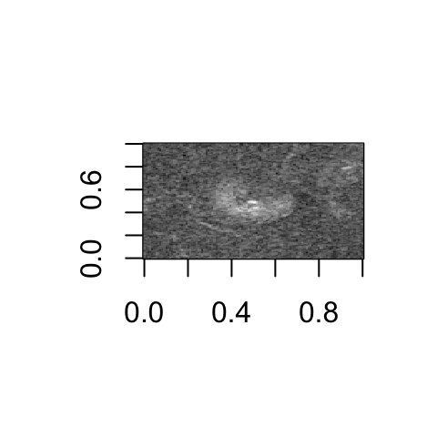

Obs 10 Type: 1 Radius: 22.02 Number Volcanoes: 1

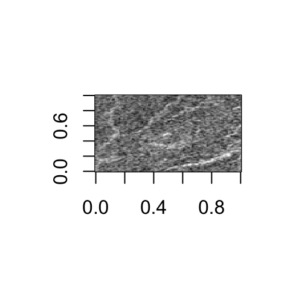

Obs 39 Type: 2 Radius: 19.31 Number Volcanoes: 1

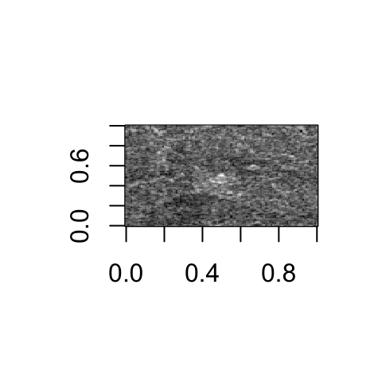

Obs 1 Type: 3 Radius: 17.46 Number of Volcanoes: 1

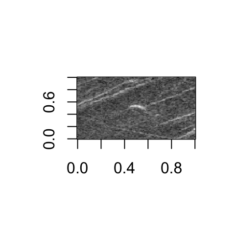

Obs 30 Type: 4 Radius: 6.40 Number Volcanoes: 1

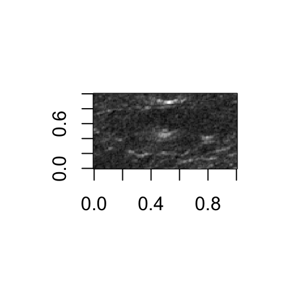

Obs 289 Type: 1 Radius: 11.05 Number Volcanoes: 2

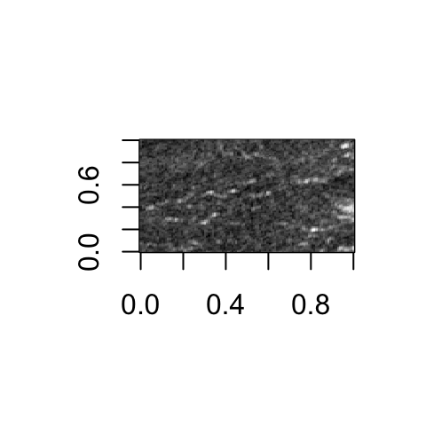

Obs 2 No Volcano

```r
volplot(train_data, 10)
```

### Data Summary

To facilitate the analysis process and explore the data, we have summarized the data. The `ggplot` has been used to visualize the training set labels. **Figure 8** shows that only 1000 images in the training dataset have volcanoes. **Figure 9** shows that within 1000 images that have volcanoes, how clearly we can identify the volcanoes. **Figure 10** shows how many volcanoes there are in each image. The number of volcanoes ranges from 0 to 5.

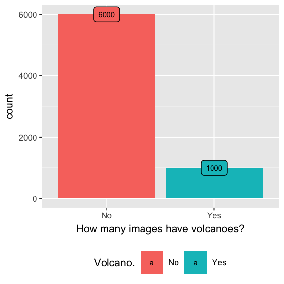

How many images have volcanoes?

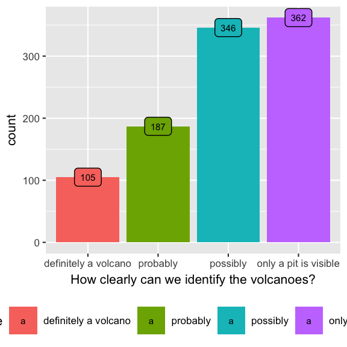

How clealy can we identify the volcanoes?

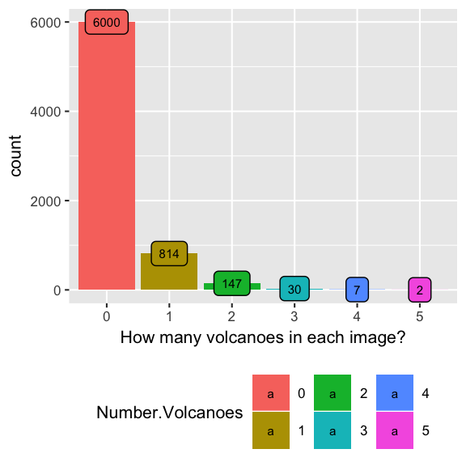

How many volcanoes are there in each image?

## A. Classification for if there is any volcano

### Linear Dicriminant Analysis (LDA) and Quadratic Discriminant Analysis (QDA)

Linear Dicriminant Analysis was applied by using `MASS` package. Prediction using LDA analysis produced adequate results, however, it output warning of ‘variables are collinear’. Implementing QDA analysis produced error of ‘some group is too small for qda’. The warning and error produced may be that our parameter (pixel) number is too large. Therefore to solve this problem, we try to use other algorithms to fit the dataset.

### Lasso Regression

Lasso regression was applied as it can perform variable selection, which is suitable in the project situation : having more parameters than observations. To apply Lasso Regression,`glmnet` package was implemented. We first selected reasonable interval for tuning parameter $\lambda$ by examing cross-validation error. After that, we did the model selection by using glmnet and use the “lambda.min” as final tuning parameter. By using the cross-validation error data, we identified the interval, (-6.5, -5) selected 470 important pixels. The prediction using those pixels yielded a good start, a high prediction accuracy.

### Logistic Regression

Before performing logistic regression, we used two variable selection methods to reduce dimension. 400 pixels were selected by using Marginal Screening and 470 pixels were selected by using above Lasso Regression. Then, we applyed logistic regressions on those 2 sets of selected pixels repectively. We then recorded their F1 score and AUC for classification, and they showed that Lasso selected pixels performed better than Marginal Screening method.

```r
# code for marginal screening
cl <- makeCluster(3)
registerDoParallel(cl)
pre = Sys.time()
vol_results <- foreach(j = 1:ncol(train.x),
    .packages = "lme4", .combine = "rbind") %dopar%
    {
        pix = scale(train.x[, j])
        fit.glm <- summary(glm(as.factor(train.y) ~
            pix, family = "binomial"))
        fit.glm$coefficients[2,
            4]
    }
Sys.time() - pre
stopCluster(cl)
# save(vol_results, file =
# 'vol_result.RData')
rownames(vol_results) = colnames(train.x)
colnames(vol_results) = "glm.p value"
totalpix = 400
sortedresults = as.matrix(vol_results[order(vol_results),
    ])
usepix = names(sortedresults[1:totalpix,
    ])
top_pix = match(usepix, rownames(vol_results))
```

```r
# code for logistic regression:
logmodel = glm(as.factor(volcano) ~
    ., data = training, family = "binomial")
train.error = (predict(logmodel,
    data.frame(sel.pix), type = "response") >
    0.5)
log_pred = (predict(logmodel, data.frame(test.pipx),
    type = "response") > 0.5)
table(log_pred, test.y)
```

### Neural Network

Convolutional neural networks (CNNs) have been applied widely in image and video recognition and classification. CNNs are made up of neurons with learnable weights and bias. Therefore, CNNs were used in the project for seeking better classfication results. Some pooling layers were added into the models to progressively reduce the spatial size and the amount of parameters and computation in the network. The raw data *train_images* and *test_images* was converted into numeric variables and reshaped into 3D array with dimension 7000 $\times$ 110 $\times$ 110 and 2734 $\times$ 110 $\times$ 110 respectively. The pixels were shrinked from 0-255 to 0-1 by dividing each pixel by 255. The target label (Volcano?) was converted into categorical variable for classification. The neural network models yielded efficient and satisfying classification results. The loss function is relatively low, indicating the models are good.

**Figure 11** shows the result of the first neural network model which is designed to classify whether an image contains a volcano. The model used 20% of the training data as validation data.

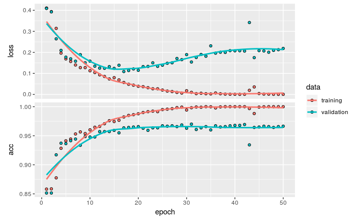

Neural Network to classify whether an image contains volcanoes

The loss function and accuracy:

```
## $loss
## [1] 0.3018637
##
## $acc
## [1] 0.9568398
```